# Econ 320 Python Final Project

## What Affects a Movie Score

## Minh-Thy Tyler, Ellen Cheng, Kendall Pollard, Anish Nashine

# Introduction and Motivation

```python
from PIL import Image
```

[figure not shown]

```python
image = Image.open('/Users/minh-thytyler/Desktop/2022-2023/ECON 320/Econ 320 Lab/thumbnail_image001.jpeg')
image
```

## *Research Question*

[figure not shown]

```python
image2 = Image.open('/Users/minh-thytyler/Desktop/2022-2023/ECON 320/Econ 320 Lab/thumbnail_image002.png')
image2
```

For our research question, we will be investigating potential factors that could influence a movie’s IMDb score. This topic is interesting because the opinion of viewers of movies may vary based on a plethora of factors. The length of the movie, the language the movie is in, genre, the number of people that viewed it, and the number of people that reviewed it all may affect a movie’s score. It is interesting to see reviews of movies and wonder why some rate better than others; using a regression, we can see which variables have more weight on the score, and we can analyze why that may be the case.

## *Context*

[figure not shown]

```python
image3 = Image.open('/Users/minh-thytyler/Desktop/2022-2023/ECON 320/Econ 320 Lab/thumbnail_image003.png')
image3
```

The “world” where this would happen is the world of movie reviews, but in this case it is regular citizens, not licensed movie critics, that offer their opinions. Movie critics could be included and offer their opinion, but the website is open to the public to offer a review, so more regular people have the chance to review movies and give them scores. Because many of the movies are American movies in English, the “world” may include more English-speakers than non-English speakers, however there are still a plethora of other languages and countries. This “world” would affect anyone who watches and likes movies.

## *Relevance*

These findings are relevant to consumers who are planning to purchase movies, directors trying to make movies that people like, actors who are trying to make money acting and therefore also interested in what factors make people like movies, and finally anyone interested to see what affects movie scores. For consumers, they can determine if a movie is worth their money by viewing its score, but it would be more beneficial to them to know which factors influence the score. For example, if they don't mind a longer movie but our regression shows that most people rate longer movies lower, that specific consumer can determine if their demand may be different than most people. Directors and actors can see what factors affect a score and possibly align their future films with these factors to see if they can make more money. Finally, the general public can simply see how certain movies are rated based on which factors.

## *Supporting Evidence*

To prove why our topic and research question is relevant, we found a study on the effect movie reviews have on consumers. Jacob R. Pentheny, a PHD student asked the question: “Can online word-of-mouth such as professional reviews by critics and comments and descriptive reviews by consumers positively or negatively affect an individual consumer’s decision to purchase a movie ticket?" (Pentheny, 2). His findings showed that reviews do in fact have an effect on consumers, which again proves why what affects a review is important per our research question. Another research paper by Robert O. Wyatt and David P. Badger asked: "can a critical review stimulate or discourage audience interest in attending a particular film, and can a review significantly affect the audience's evaluation of a film afterwards?" (Wyatt, 1). Wyatt and Badger found that critical reviews do in fact have statistical significance in determining how an audience feels about the film. This means that our research question is important because we are looking into what affects those reviews, and based on their evidence, that review could mean something in terms of how well a movie does for the effect of these reviews. A third study researched "Quantitative approaches for evaluating the influence of films using the IMDb database" which is extremely relevant to our question because they specifically look at the IMBd database (Canet, 1). Fernando J Canet looks into the most influential movies of all time and determines what about those movies made them influencial. Reviews of the most influencial movies are bound to play a role in their influence, and our analysis can offer background information on what makes a review better or worse that could then influence the movie's popularity. These studies offer background information that reviews do in fact affect film attendance and how much the audience likes the film, and we know intuitively, this will affect economic sales. Our research question will add to existing literature about what exactly affects a review. As for hypothesizing different regressors and what effect they will have on the imdb score, the table below includes more supporting evidence.

# Data

Our data includes movie reviews that range from the 1980s to 2016. There are categorical and numerical variables. Our dataset is quite large, with over 5,000 movies entered. Some interesting features are that a lot of the movies entered are blockbuster movies and popular actors and actresses dominate the movies on the list. We are also interested to see whether IMDb score is correlated with duration, number of voted users, and number user for reviews. Below we have included a table describing each variable we will use in our regression and a hypothesis on how that variable will affect the IMDb score.

## *General Data Description and Economic Hypothesis*

| Variables | Description | Economic Hypothesis |
| --- | --- | --- |
| Duration | This is the duration of the movie, in minutes. It is listed as an integer | We hypothesize that duration will have a negative effect. We live in a society where everyone lives a fast-paced life, so they crave quick entertainment. A longer duration of a movie would create a lo… |
| Genre | This is the genre of the movie. It is a dummy variable with documentary = 1 and all other types of genre = 0. | We hypothesize that genre will have a positive effect due to the fact that it is a dummy variable with documentary =1 and people usually rate documentaries higher. They are seen as educational, high-q… |
| Number of voted users | This is the number of users who rated the movie. | We hypothesize that the number of users who vote on the movie rating will create a negative effect. We are assuming that the reason people rate a movie is to explain why they did not like it. |
| Number of users for reviews | This is the number of users who wrote out a review for the movie. It is distinct from the number of users that voted because the voters only rated the movie on a 1-10 scale. The reviewers wrote out an… | We hypothesize that the number of users who wrote reviews will create a negative effect, for the same reasons as number of users who vote in general will create a negative effect. |
| Language | This is the language that the movie is in. It is a dummy variable with English = 1 and other languages = 0. | We hypothesize that the movie being in English will create a positive effect becasue the imbd website is in English and many of the movies are, so just based on higher numbers, English movies are boun… |
| Country | This is the country that movie was made in. It is a dummy variable with the movie being made in USA = 1 and other = 0. | We hypothesize that the movie being made in the USA would create a positive effect because there is a lot of funding in the film industry. We found that according to a 2013 survey by Consumer Reports … |

## *Charts and Plots*

```python
# Packages
import pandas as pd
import numpy as np
import seaborn as sns
import matplotlib.pyplot as plt
import statsmodels.formula.api as smf
from stargazer.stargazer import Stargazer
from IPython.core.display import HTML
from scipy.stats import pearsonr

# Data from
#https://data.world/himan/imdb-movie-dataset
```

```python
# import csv file, change this based on where you stored your csv (this is specific to mine)
# movie = pd.read_csv(r'/Users/minh-thytyler/Desktop/2022-2023/ECON 320/Econ 320 Lab/final project/movie_data.csv')

movie = pd.read_csv(r'/Users/minh-thytyler/Desktop/2022-2023/ECON 320/Econ 320 Lab/final project/movie_data.csv')


#To reference variable names
#print(df)
```

### Descriptive statistics for duration, number of voted users, number user for reviews, and IMDb Score

```python
#Descriptive statistics of variables: duration, num_voted_users, num_user_for_reviews, and imdb_score
burberry = movie[['imdb_score','duration', 'num_voted_users','num_user_for_reviews']].agg(['mean','std','min','max'])
burberry.round(2)
```

|  | imdb_score | duration | num_voted_users | num_user_for_reviews |
| --- | --- | --- | --- | --- |
| mean | 6.44 | 107.2 | 83668.16 | 272.77 |
| std | 1.13 | 25.2 | 138485.26 | 377.98 |
| min | 1.60 | 7.0 | 5.00 | 1.00 |
| max | 9.50 | 511.0 | 1689764.00 | 5060.00 |

### Scatterplots of numerical variables vs IMDb Score

Looking at the graph below, there seems to be no correlation between the duration of a movie and its IMDb score. However, we will still include it in our regression model because graphs never tell the entire story.

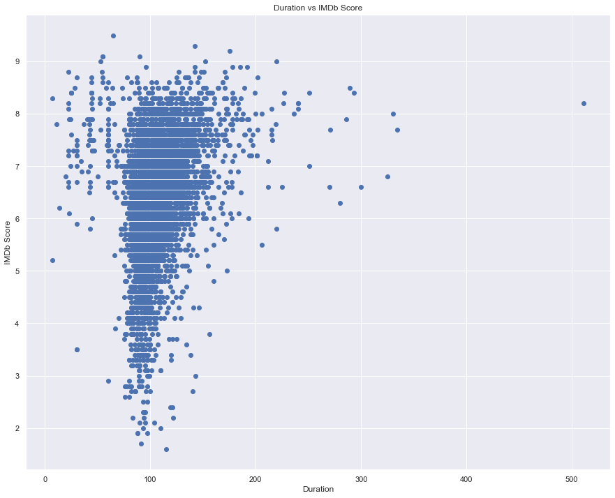

```python
#creating scatter plot of duration against imdb_score
plt.scatter(movie['duration'], movie['imdb_score'])
plt.title('Duration vs IMDb Score')
plt.xlabel('Duration')
plt.ylabel('IMDb Score')
plt.show()
```

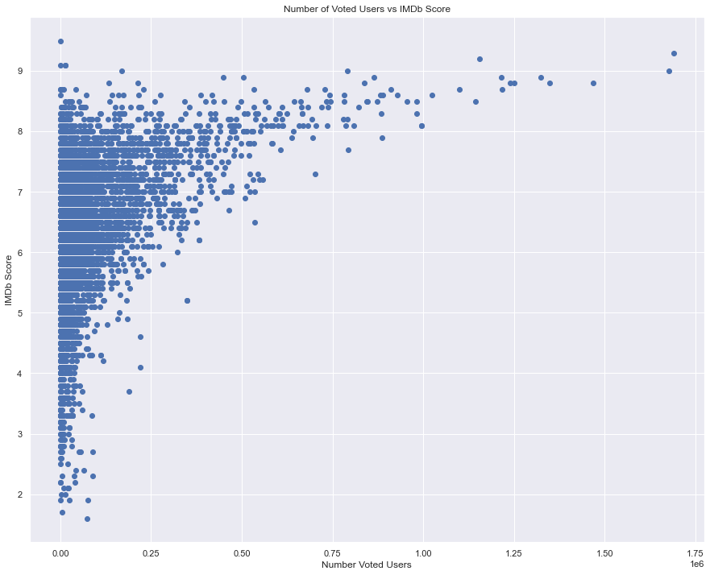

```python
#creating scatter plot of num_voted_users against imdb_score
plt.scatter(movie['num_voted_users'], movie['imdb_score'])

plt.title('Number of Voted Users vs IMDb Score')
plt.xlabel('Number Voted Users')
plt.ylabel('IMDb Score')
plt.show()
```

Looking at the graph below, there seems to be no correlation between the number user for reviews of a movie and its IMDb score. However, we will still include it in our regression model because graphs never tell the entire story.

[figure not shown]

```python
#creating scatter plot of number user for reviews against imdb_score
plt.scatter(movie['num_user_for_reviews'], movie['imdb_score'])
plt.title('Number User for Reviews vs IMDb Score')
plt.xlabel('Number User for Reviews')
plt.ylabel('IMDb Score')
plt.show()
```

## *Dummy Variables*

#### Genres

```python
#creating new df genres to seperate out descriptive stats
versace = ['Action','Documentary','Adventure','Romance','Drama','Horror','Thriller','Sci-Fi','Comedy']
genres = movie.loc[movie['genres'].isin(versace)]

#The mean of numerical variables grouped by genres
genres[['genres','imdb_score','duration', 'num_voted_users','num_user_for_reviews']].groupby('genres').agg('mean').round(2)
```

| genres | imdb_score | duration | num_voted_users | num_user_for_reviews |
| --- | --- | --- | --- | --- |
| Action | 5.97 | 106.18 | 111592.00 | 373.64 |
| Adventure | 6.10 | 132.00 | 127376.00 | 576.67 |
| Comedy | 5.86 | 92.58 | 60007.50 | 181.23 |
| Documentary | 7.12 | 87.90 | 5478.16 | 49.88 |
| Drama | 6.93 | 110.31 | 55255.82 | 194.84 |
| Horror | 5.54 | 94.99 | 53505.89 | 368.23 |
| Romance | 5.75 | 114.50 | 592.00 | 6.67 |
| Sci-Fi | 4.77 | 84.67 | 1498.67 | 29.33 |
| Thriller | 5.35 | 103.35 | 4142.90 | 32.60 |

It is interesting to see that the genres that have higher average IMDb score than the mean of all genres (6.44) are Documentary and Drama. The rest of the genres have a lower IMDb score. (remember to note that we are only taking into consideration movies with one genre!)

The genre of the movie seems to have an influence on the IMDb score of the movie. Documentaries have the highest average IMDb score and Sci-Fi has the lowest IMDb score. Because it has the highest average IMDb score, we are interested to see if a movie being in the Documentary genre positively influences IMDb score and will make it our dummy variable.

#### Languages

*For our boxplot, we will only be including the IMDb scores from countries and languages with the most movie data. Doing this to make the boxplot easier to read*

#### Seperating out the languages that have the most data

```python
#Finding number movie data in each language
#pd.DataFrame(movie['language'].value_counts().head(10))
```

```python
#averages of numeric variables for top 10 languages with most data
top10lang[['language','imdb_score','duration', 'num_voted_users','num_user_for_reviews']].groupby('language').agg('mean').round(2)
```

| language | imdb_score | duration | num_voted_users | num_user_for_reviews |
| --- | --- | --- | --- | --- |
| Cantonese | 6.95 | 97.45 | 28169.73 | 109.91 |
| English | 6.40 | 106.78 | 87040.26 | 282.50 |
| French | 7.04 | 103.95 | 26363.74 | 98.41 |
| German | 7.34 | 128.89 | 69346.84 | 191.42 |
| Hindi | 6.63 | 142.04 | 16387.00 | 96.71 |
| Italian | 7.23 | 109.18 | 70861.55 | 155.00 |
| Japanese | 7.39 | 116.78 | 81805.11 | 212.11 |
| Mandarin | 6.79 | 112.04 | 35709.08 | 201.50 |
| Russian | 6.36 | 108.73 | 16655.73 | 92.55 |
| Spanish | 6.94 | 106.58 | 43893.40 | 137.48 |

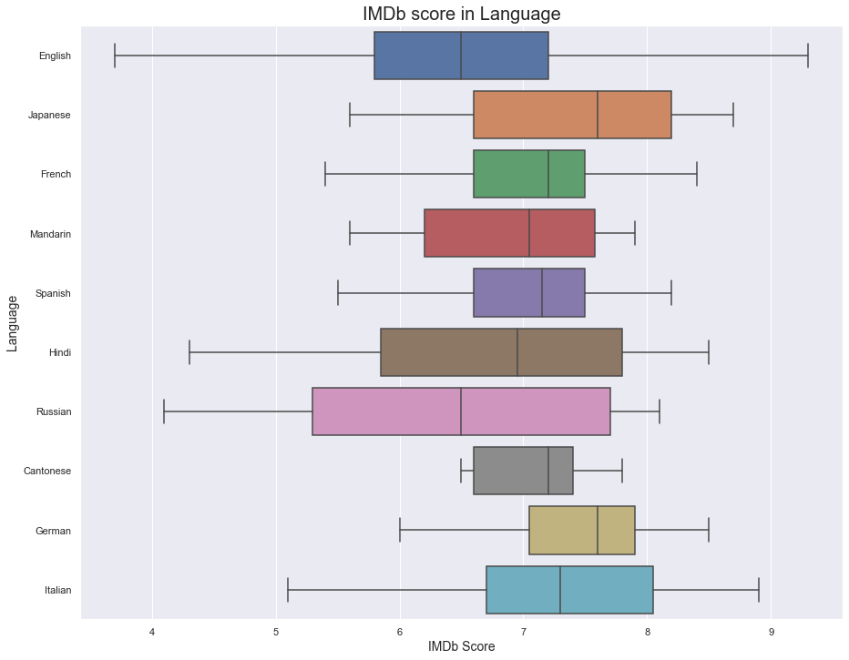

```python
#Creating a box plot of IMDb scores top 10 languages

sns.boxplot(x = top10lang['imdb_score'], y = top10lang['language'], showfliers = False)
sns.set(rc={'figure.figsize':(15,12)})
plt.title('IMDb score in Language',fontsize=20)
plt.xlabel('IMDb Score',fontsize=14)
plt.ylabel('Language', fontsize=14)
plt.show()
```

#### Seperating out the countries that have the most data

```python
#Finding number of movie data in each country
#pd.DataFrame(movie['country'].value_counts().head(10))
```

```python
#Creating a new df of top 10 countries with most data
gucci = ['USA','UK','France','Canada','Germany','Australia','India','Spain','China','Japan']
top10coun = movie.loc[movie['country'].isin(gucci)]
```

```python
#averages of numeric variables for top 10
top10coun[['country','imdb_score','duration', 'num_voted_users','num_user_for_reviews']].groupby('country').agg('mean').round(2)
```

| country | imdb_score | duration | num_voted_users | num_user_for_reviews |
| --- | --- | --- | --- | --- |
| Australia | 6.51 | 105.52 | 66645.85 | 238.65 |
| Canada | 6.16 | 99.40 | 31072.87 | 165.93 |
| China | 6.62 | 114.87 | 32015.60 | 131.53 |
| France | 6.68 | 108.94 | 52230.94 | 188.69 |
| Germany | 6.34 | 110.21 | 78803.38 | 313.65 |
| India | 6.53 | 139.39 | 15243.62 | 90.82 |
| Japan | 6.95 | 114.48 | 70997.65 | 209.22 |
| Spain | 6.82 | 105.94 | 74811.09 | 196.18 |
| UK | 6.82 | 109.91 | 79807.24 | 275.87 |
| USA | 6.37 | 106.44 | 91053.02 | 287.97 |

[figure not shown]

```python
#Creating a box plot of IMDb scores top 10 countries

sns.boxplot(x = top10coun['imdb_score'], y = top10coun['country'], showfliers = False)
sns.set(rc={'figure.figsize':(15,12)})
plt.title('IMDb score in Countries',fontsize=20)
plt.xlabel('IMDb Score',fontsize=14)
plt.ylabel('Country', fontsize=14)
plt.show()
```

It is interesting to see that movies filmed in Canada, the US, and Germany have lower IMDb scores than the total average IMDb score (6.44). Taking this into consideration, English is spoken in Canada, the UK, the US, and Australia. Maybe the reason why English movies have a lower average IMDb score is because movies filmed in the US and Canada bring this average down. Movies in Japan have the highest average IMDb score.

Because English and USA has the most data, we will make them our dummy variable ==1. We are interested to see if movies made in the USA and in English will influence the IMDb score

**Genres: Documentary ==1, all else == 0; Language: English == 1, all else == 0; Country: USA == 1, all else == 0.**

```python
#for genre
movie['isDocumentary']= (movie['genres']=='Documentary')
#movie['isDocumentary'].value_counts()
```

```python
#for language
movie['isEnglish']= (movie['language']=='English')
#movie['isEnglish'].value_counts()
```

```python
#for country
movie['isUSA']= (movie['country']=='USA')
#movie['isUSA'].value_counts()
```

# Testing for Assumptions (ex. OVB, Multicollinearity, Heteroskedasticity)

### Omitted Variable Bias

We are constrained by the limits of our dataset. There are not many quantitative variables that we have in use for our analysis. We do have complete data on the quantitative independent variables in our possession, which are: duration, number of written reviews, and number of votes.

Though there may be other quantitative variables that could affect a movie's IMDB rating (ex: # of years experience for lead actor), these are not contained within our dataset, and there is no way to account for it. Still, it is good to keep in mind the limitations of our dataset and discuss it when talking about our final results

### Multicollinearity

If multicollinearity fails between variables, then one of the variables must be taken out. Multicollinearity is an assuption where one variable cannot be a linear transformation of another variable. The only two variables that would even need to be tested for this are between "number of written reviews" and "number of votes". Though I am sure that these variables are correlated (and even highly so), all we need to ensure is that one is not a linear transformation of the other.

```python
# Cleaning data to get rid of rows that have no values for either # of reviews

movie1 = movie.dropna(axis=0, subset=['num_user_for_reviews'])

user_votes = movie1['num_voted_users']
user_reviews = movie1['num_user_for_reviews']

corr, _ = pearsonr(user_votes, user_reviews)
print('Correlation Between # of votes and written reviews: %.3f' % corr)
```

```
Correlation Between # of votes and written reviews: 0.798
```

So, looking at these results, there is still a high correlation between the number of votes and number of written reviews. This was expected. However, there is not a direct linear relationship (which would imply a correlation of 1) between these two variables. Therefore, it is still valid to place within our dataset.

### Heteroskedasticity

Regressions are more powerful when they are homoskedastic. Homoskedasticity is an important assumption that we employ. In modern times, since the advent of Robust White standard errors, we can just make a regression table with White standard errors and the default standard error, just so we can see the difference.

If we only used default standard errors, then they would be too small for a heteroskedastic model (which we have). This is why we use White standard errors -- they help correct for heteroskedasticity in models that are not homoskedastic.

Below, when we do the regression, we will demonstrate both versions -- White Standard Error and Regular Standard Error.

# Methodology/Empirical Model

For clarification, we will be running two regressions. One with default standard errors, and one with Robust White standard errors. Both can provide us with valuable information about how our data changes when accounting for heteroskedasticity.

```python
# Regression with regular standard errors

mod = smf.ols(formula='imdb_score ~ duration + num_voted_users + num_user_for_reviews',
              data=movie).fit()

#regression w/ Documentary
mod1 = smf.ols(formula='imdb_score ~ duration + num_voted_users + num_user_for_reviews + isDocumentary',
              data=movie).fit()

#regression w/ English
mod2 = smf.ols(formula='imdb_score ~ duration + num_voted_users + num_user_for_reviews +isEnglish',
              data=movie).fit()

#regression w/ USA
mod3 = smf.ols(formula='imdb_score ~ duration + num_voted_users + num_user_for_reviews +isUSA',
              data=movie).fit()

#regression w/ English and USA
mod4 = smf.ols(formula='imdb_score ~ duration + num_voted_users + num_user_for_reviews +isEnglish + isUSA',
              data=movie).fit()

#Regression w/ all
mod5 = smf.ols(formula='imdb_score ~ duration + num_voted_users + num_user_for_reviews + isDocumentary+isEnglish + isUSA',
              data=movie).fit()
```

```python
# Regression with White Standard Errors

mod_w = smf.ols(formula='imdb_score ~ duration + num_voted_users + num_user_for_reviews',
              data=movie).fit(cov_type = 'HC0')
#regression w/ Documentary
mod1_w = smf.ols(formula='imdb_score ~ duration + num_voted_users + num_user_for_reviews + isDocumentary',
              data=movie).fit(cov_type ='HC0')

#regression w/ English
mod2_w = smf.ols(formula='imdb_score ~ duration + num_voted_users + num_user_for_reviews +isEnglish',
              data=movie).fit(cov_type ='HC0')

#regression w/ USA
mod3_w = smf.ols(formula='imdb_score ~ duration + num_voted_users + num_user_for_reviews +isUSA',
              data=movie).fit(cov_type ='HC0')

#regression w/ English and USA
mod4_w = smf.ols(formula='imdb_score ~ duration + num_voted_users + num_user_for_reviews +isEnglish + isUSA',
              data=movie).fit(cov_type ='HC0')

#Regression w/ all
mod5_w = smf.ols(formula='imdb_score ~ duration + num_voted_users + num_user_for_reviews + isDocumentary+isEnglish + isUSA',
              data=movie).fit(cov_type ='HC0')
```

Our thought process that we took when choosing our model was how we could accurately show the data and the best way to find a statistically significant relationship. First, we analyzed the relationship between IMDb score and the numerical variables (duration, number user for reviews, voted users) through scatterplots because scatterplots help visualize the data as well as if there’s any trend between the independent and dependent variables. We created dummy variables to cover any influence the none-numerical variables may have had. Since these variables aren’t numerical, we used box plots to find trends within IMDb scores compared to variables such as language and country. We believe that this approach to our models helps identify trends in the data in a clear way.

The director name variable could be important but we decided not to include it. This is because a celebrity director could have an impact on IMDb scores based on awareness alone, whereas a no-name director would garner less attraction around their movie and thus, less ratings to contribute to their IMDb score. We decided not to include this variable because it is hard to measure and it’s hard to quantify the impact of a person.

#### Default Standard Error Regressions

```python
prada = Stargazer([mod, mod1, mod2, mod3, mod4, mod5])
prada.covariate_order(['Intercept', 'duration','num_voted_users','num_user_for_reviews','isDocumentary[T.True]','isEnglish[T.True]','isUSA[T.True]'])
prada.rename_covariates({'duration': 'Duration', 'num_voted_users': 'Number of Voted Users','num_user_for_reviews': 'Number User for Reviews','isDocumentary[T.True]': 'Documentary: True','isEnglish[T.True]': 'English: True','isUSA[T.True]': 'USA: True'})


#Change names of covariates
#setting table style
prada.title('Default Regressions')
HTML(prada.render_html())
```

Default Regressions

|  | *Dependent variable:imdb_score* |  |  |  |  |  |
| --- | --- | --- | --- | --- | --- | --- |
|  | (1) | (2) | (3) | (4) | (5) | (6) |
| Intercept | 5.446*** | 5.405*** | 6.223*** | 5.780*** | 6.264*** | 6.223*** |
|  | (0.063) | (0.063) | (0.085) | (0.069) | (0.085) | (0.085) |
| Duration | 0.007*** | 0.008*** | 0.006*** | 0.007*** | 0.006*** | 0.007*** |
|  | (0.001) | (0.001) | (0.001) | (0.001) | (0.001) | (0.001) |
| Number of Voted Users | 0.000*** | 0.000*** | 0.000*** | 0.000*** | 0.000*** | 0.000*** |
|  | (0.000) | (0.000) | (0.000) | (0.000) | (0.000) | (0.000) |
| Number User for Reviews | -0.000*** | -0.000*** | -0.000*** | -0.000*** | -0.000*** | -0.000*** |
|  | (0.000) | (0.000) | (0.000) | (0.000) | (0.000) | (0.000) |
| Documentary: True |  | 1.045*** |  |  |  | 1.042*** |
|  |  | (0.144) |  |  |  | (0.141) |
| English: True |  |  | -0.755*** |  | -0.593*** | -0.595*** |
|  |  |  | (0.057) |  | (0.062) | (0.061) |
| USA: True |  |  |  | -0.371*** | -0.231*** | -0.229*** |
|  |  |  |  | (0.033) | (0.036) | (0.036) |
| Observations | 5,010 | 5,010 | 5,010 | 5,010 | 5,010 | 5,010 |
| R<sup>2</sup> | 0.200 | 0.208 | 0.227 | 0.219 | 0.234 | 0.242 |
| Adjusted R<sup>2</sup> | 0.199 | 0.207 | 0.227 | 0.219 | 0.233 | 0.241 |
| Residual Std. Error | 1.004 (df=5006) | 0.999 (df=5005) | 0.987 (df=5005) | 0.991 (df=5005) | 0.983 (df=5004) | 0.977 (df=5003) |
| F Statistic | 416.458*** (df=3; 5006) | 328.768*** (df=4; 5005) | 367.890*** (df=4; 5005) | 351.874*** (df=4; 5005) | 305.068*** (df=5; 5004) | 266.091*** (df=6; 5003) |
| Note: | *p<0.1; **p<0.05; ***p<0.01 |  |  |  |  |  |

#### Robust White Standard Error Regressions

```python
prada = Stargazer([mod_w, mod1_w, mod2_w, mod3_w, mod4_w, mod5_w])
prada.covariate_order(['Intercept', 'duration','num_voted_users','num_user_for_reviews','isDocumentary[T.True]','isEnglish[T.True]','isUSA[T.True]'])
prada.rename_covariates({'duration': 'Duration', 'num_voted_users': 'Number of Voted Users','num_user_for_reviews': 'Number User for Reviews','isDocumentary[T.True]': 'Documentary: True','isEnglish[T.True]': 'English: True','isUSA[T.True]': 'USA: True'})
#EDIT

#Change names of covariates
#setting table style
prada.title('Robust White Standard Error Regressions')
HTML(prada.render_html())
```

Robust White Standard Error Regressions

|  | *Dependent variable:imdb_score* |  |  |  |  |  |
| --- | --- | --- | --- | --- | --- | --- |
|  | (1) | (2) | (3) | (4) | (5) | (6) |
| Intercept | 5.446*** | 5.405*** | 6.223*** | 5.780*** | 6.264*** | 6.223*** |
|  | (0.074) | (0.075) | (0.090) | (0.079) | (0.090) | (0.090) |
| Duration | 0.007*** | 0.008*** | 0.006*** | 0.007*** | 0.006*** | 0.007*** |
|  | (0.001) | (0.001) | (0.001) | (0.001) | (0.001) | (0.001) |
| Number of Voted Users | 0.000*** | 0.000*** | 0.000*** | 0.000*** | 0.000*** | 0.000*** |
|  | (0.000) | (0.000) | (0.000) | (0.000) | (0.000) | (0.000) |
| Number User for Reviews | -0.000*** | -0.000*** | -0.000*** | -0.000*** | -0.000*** | -0.000*** |
|  | (0.000) | (0.000) | (0.000) | (0.000) | (0.000) | (0.000) |
| Documentary: True |  | 1.045*** |  |  |  | 1.042*** |
|  |  | (0.146) |  |  |  | (0.143) |
| English: True |  |  | -0.755*** |  | -0.593*** | -0.595*** |
|  |  |  | (0.052) |  | (0.059) | (0.058) |
| USA: True |  |  |  | -0.371*** | -0.231*** | -0.229*** |
|  |  |  |  | (0.033) | (0.036) | (0.036) |
| Observations | 5,010 | 5,010 | 5,010 | 5,010 | 5,010 | 5,010 |
| R<sup>2</sup> | 0.200 | 0.208 | 0.227 | 0.219 | 0.234 | 0.242 |
| Adjusted R<sup>2</sup> | 0.199 | 0.207 | 0.227 | 0.219 | 0.233 | 0.241 |
| Residual Std. Error | 1.004 (df=5006) | 0.999 (df=5005) | 0.987 (df=5005) | 0.991 (df=5005) | 0.983 (df=5004) | 0.977 (df=5003) |
| F Statistic | 377.905*** (df=3; 5006) | 285.815*** (df=4; 5005) | 308.953*** (df=4; 5005) | 310.281*** (df=4; 5005) | 257.929*** (df=5; 5004) | 218.288*** (df=6; 5003) |
| Note: | *p<0.1; **p<0.05; ***p<0.01 |  |  |  |  |  |

# Results

Overall, throughout the regressions, it was clear that neither the number of reviews or the number of ratings in general was associated with creating a difference in the numerical IMDb scores. The coeffecient is 0.000 for num_voted_users and num_user_for_reviews, making this completely moot in terms of having an effect or association on the overall score.

Duration has an extremely slight but, ultimately, negligible positive correlation with scores throughout all specifications of regressions we did. The coefficients were all less than 0.01, and with a rating system that goes from 0 to 10, this is a forgettable difference in scores.

However, our dummy variables proved useful in finding some interesting results. Looking at regression #2, it seems that having a documentary is associated with a 1.045 point increase in IMDb rating. This is an interesting find, and demonstrates what genres people may associate with better filmaking and quality. Documentaries tend to be well-produced, which can help account for this difference.

With English movies from the USA, we can see which of "USA" or "English" is the bigger factor in the lower scores -- through this regression it seems that it is the "English" portion, associated with a 0.593 decrease in score, as opposed to just "USA", the coefficient of which is -0.231.

In the final regression, similar results hold from prior regressions. An IMDb film being a documentary was associated with a ~ 1 point increase, with the "English" and "USA" coefficients displaying similarly negative values.

# Conclusion

Our study tried to identify a relationship between the number of votes and reviews and the duration of a movie with the movie’s IMDb score. We did this through running 6 regressions with each regression having a different combination of variables. We also inserted dummy variables. Our results showed that only our dummy variables had some sort of effect, because the duration and number of votes and reviews didn’t seem to have an effect at all, and their coefficients were close to zero. In the future, we recommend a data set with more quantitative variables and a data set without distinct genres so we could also filter by genre. A shortcoming of our data set is that there is no column that shows whether the actresses are male or female, which would have been interesting to see if gender has an effect on rating as well, which is a shortcoming that could be circumvented by adding a gender column.